# Risk Factor Analysis

## Outcome Variable

**Outcome Variable:** haz

## Predictor Variables

**Intervention Variable:** exclfeed3

**Adjustment Set:**

- arm
- sex
- brthmon
- W_mage
- meducyrs
- feducyrs
- hhwealth_quart
- hfoodsec
- W_mhtcm
- W_mwtkg
- W_mbmi
- vagbrth
- W_gagebrth
- W_birthwt
- W_birthlen
- W_nrooms
- W_nchldlt5
- month
- W_parity
- impfloor
- impsan
- safeh20
- delta_W_mage
- delta_meducyrs
- delta_feducyrs
- delta_hhwealth_quart
- delta_hfoodsec
- delta_W_mhtcm
- delta_W_mwtkg
- delta_W_mbmi
- delta_vagbrth
- delta_W_gagebrth
- delta_W_birthwt
- delta_W_birthlen
- delta_W_nrooms
- delta_W_nchldlt5
- delta_month
- delta_W_parity
- delta_impfloor
- delta_impsan
- delta_safeh20

## Stratifying Variables

The analysis was stratified on these variable(s):

- agecat
- studyid
- country

## Data Summary

| agecat | studyid | country | exclfeed3 | n_cell | n | outcome_variable |
| --- | --- | --- | --- | --- | --- | --- |
| Birth | ki0047075b-MAL-ED | BANGLADESH | 1 | 138 | 215 | haz |
| Birth | ki0047075b-MAL-ED | BANGLADESH | 0 | 77 | 215 | haz |
| Birth | ki0047075b-MAL-ED | BRAZIL | 1 | 12 | 57 | haz |
| Birth | ki0047075b-MAL-ED | BRAZIL | 0 | 45 | 57 | haz |
| Birth | ki0047075b-MAL-ED | INDIA | 1 | 24 | 41 | haz |
| Birth | ki0047075b-MAL-ED | INDIA | 0 | 17 | 41 | haz |
| Birth | ki0047075b-MAL-ED | NEPAL | 1 | 8 | 26 | haz |
| Birth | ki0047075b-MAL-ED | NEPAL | 0 | 18 | 26 | haz |
| Birth | ki0047075b-MAL-ED | PERU | 1 | 49 | 223 | haz |
| Birth | ki0047075b-MAL-ED | PERU | 0 | 174 | 223 | haz |
| Birth | ki0047075b-MAL-ED | SOUTH AFRICA | 1 | 12 | 100 | haz |
| Birth | ki0047075b-MAL-ED | SOUTH AFRICA | 0 | 88 | 100 | haz |
| Birth | ki0047075b-MAL-ED | TANZANIA, UNITED REPUBLIC OF | 1 | 17 | 102 | haz |
| Birth | ki0047075b-MAL-ED | TANZANIA, UNITED REPUBLIC OF | 0 | 85 | 102 | haz |
| Birth | ki1000108-CMC-V-BCS-2002 | INDIA | 1 | 4 | 4 | haz |
| Birth | ki1000108-CMC-V-BCS-2002 | INDIA | 0 | 0 | 4 | haz |
| Birth | ki1000108-IRC | INDIA | 1 | 0 | 10 | haz |
| Birth | ki1000108-IRC | INDIA | 0 | 10 | 10 | haz |
| Birth | ki1000109-EE | PAKISTAN | 1 | 35 | 35 | haz |
| Birth | ki1000109-EE | PAKISTAN | 0 | 0 | 35 | haz |
| Birth | ki1000304b-SAS-CompFeed | INDIA | 1 | 346 | 364 | haz |
| Birth | ki1000304b-SAS-CompFeed | INDIA | 0 | 18 | 364 | haz |
| Birth | ki1017093b-PROVIDE | BANGLADESH | 1 | 387 | 539 | haz |
| Birth | ki1017093b-PROVIDE | BANGLADESH | 0 | 152 | 539 | haz |
| Birth | ki1101329-Keneba | GAMBIA | 1 | 1198 | 1356 | haz |
| Birth | ki1101329-Keneba | GAMBIA | 0 | 158 | 1356 | haz |
| Birth | ki1113344-GMS-Nepal | NEPAL | 1 | 380 | 458 | haz |
| Birth | ki1113344-GMS-Nepal | NEPAL | 0 | 78 | 458 | haz |
| Birth | kiGH5241-JiVitA-3 | BANGLADESH | 1 | 12014 | 13276 | haz |
| Birth | kiGH5241-JiVitA-3 | BANGLADESH | 0 | 1262 | 13276 | haz |

[output cut: 64 more lines]

The following strata were considered:

- agecat: 24 months, studyid: ki0047075b-MAL-ED, country: BANGLADESH
- agecat: 24 months, studyid: ki0047075b-MAL-ED, country: BRAZIL
- agecat: 24 months, studyid: ki0047075b-MAL-ED, country: INDIA
- agecat: 24 months, studyid: ki0047075b-MAL-ED, country: NEPAL
- agecat: 24 months, studyid: ki0047075b-MAL-ED, country: PERU
- agecat: 24 months, studyid: ki0047075b-MAL-ED, country: SOUTH AFRICA
- agecat: 24 months, studyid: ki0047075b-MAL-ED, country: TANZANIA, UNITED REPUBLIC OF
- agecat: 24 months, studyid: ki1000108-CMC-V-BCS-2002, country: INDIA
- agecat: 24 months, studyid: ki1000108-IRC, country: INDIA
- agecat: 24 months, studyid: ki1000109-EE, country: PAKISTAN
- agecat: 24 months, studyid: ki1017093b-PROVIDE, country: BANGLADESH
- agecat: 24 months, studyid: ki1101329-Keneba, country: GAMBIA
- agecat: 24 months, studyid: ki1113344-GMS-Nepal, country: NEPAL
- agecat: 24 months, studyid: kiGH5241-JiVitA-3, country: BANGLADESH
- agecat: 24 months, studyid: kiGH5241-JiVitA-4, country: BANGLADESH
- agecat: 6 months, studyid: ki0047075b-MAL-ED, country: BANGLADESH
- agecat: 6 months, studyid: ki0047075b-MAL-ED, country: BRAZIL
- agecat: 6 months, studyid: ki0047075b-MAL-ED, country: INDIA
- agecat: 6 months, studyid: ki0047075b-MAL-ED, country: NEPAL
- agecat: 6 months, studyid: ki0047075b-MAL-ED, country: PERU
- agecat: 6 months, studyid: ki0047075b-MAL-ED, country: SOUTH AFRICA
- agecat: 6 months, studyid: ki0047075b-MAL-ED, country: TANZANIA, UNITED REPUBLIC OF
- agecat: 6 months, studyid: ki1000108-CMC-V-BCS-2002, country: INDIA
- agecat: 6 months, studyid: ki1000108-IRC, country: INDIA
- agecat: 6 months, studyid: ki1000109-EE, country: PAKISTAN
- agecat: 6 months, studyid: ki1000304b-SAS-CompFeed, country: INDIA
- agecat: 6 months, studyid: ki1017093b-PROVIDE, country: BANGLADESH
- agecat: 6 months, studyid: ki1101329-Keneba, country: GAMBIA
- agecat: 6 months, studyid: ki1113344-GMS-Nepal, country: NEPAL
- agecat: 6 months, studyid: kiGH5241-JiVitA-3, country: BANGLADESH
- agecat: 6 months, studyid: kiGH5241-JiVitA-4, country: BANGLADESH
- agecat: Birth, studyid: ki0047075b-MAL-ED, country: BANGLADESH
- agecat: Birth, studyid: ki0047075b-MAL-ED, country: BRAZIL
- agecat: Birth, studyid: ki0047075b-MAL-ED, country: INDIA
- agecat: Birth, studyid: ki0047075b-MAL-ED, country: NEPAL
- agecat: Birth, studyid: ki0047075b-MAL-ED, country: PERU
- agecat: Birth, studyid: ki0047075b-MAL-ED, country: SOUTH AFRICA
- agecat: Birth, studyid: ki0047075b-MAL-ED, country: TANZANIA, UNITED REPUBLIC OF
- agecat: Birth, studyid: ki1000108-CMC-V-BCS-2002, country: INDIA
- agecat: Birth, studyid: ki1000108-IRC, country: INDIA
- agecat: Birth, studyid: ki1000109-EE, country: PAKISTAN
- agecat: Birth, studyid: ki1000304b-SAS-CompFeed, country: INDIA
- agecat: Birth, studyid: ki1017093b-PROVIDE, country: BANGLADESH
- agecat: Birth, studyid: ki1101329-Keneba, country: GAMBIA
- agecat: Birth, studyid: ki1113344-GMS-Nepal, country: NEPAL
- agecat: Birth, studyid: kiGH5241-JiVitA-3, country: BANGLADESH
- agecat: Birth, studyid: kiGH5241-JiVitA-4, country: BANGLADESH

### Dropped Strata

Some strata were dropped due to rare outcomes:

- agecat: Birth, studyid: ki1000108-CMC-V-BCS-2002, country: INDIA
- agecat: Birth, studyid: ki1000108-IRC, country: INDIA
- agecat: Birth, studyid: ki1000109-EE, country: PAKISTAN
- agecat: 6 months, studyid: ki1000108-CMC-V-BCS-2002, country: INDIA
- agecat: 6 months, studyid: ki1000108-IRC, country: INDIA
- agecat: 6 months, studyid: ki1000109-EE, country: PAKISTAN
- agecat: 24 months, studyid: ki1000108-CMC-V-BCS-2002, country: INDIA
- agecat: 24 months, studyid: ki1000108-IRC, country: INDIA
- agecat: 24 months, studyid: ki1000109-EE, country: PAKISTAN

## Methods Detail

We’re interested in the causal parameters $E[Y_a]$ for all values of $a \in \mathcal{A}$. These parameters represent the mean outcome if, possibly contrary to fact, we intervened to set all units to have $A=a$. Under the randomization and positivity assumptions, these are identified by the statistical parameters $\psi_a=E_W[E_{Y|A,W}(Y|A=a,W)]$. In addition, we’re interested in the mean of $Y$, $E[Y]$ under no intervention (the observed mean). We will estimate these parameters by using SuperLearner to fit the relevant likelihood factors – $E_{Y|A,W}(Y|A=a,W)$ and $p(A=a|W)$, and then updating our likelihood fit using a joint TMLE.

For unadjusted analyses ($W=\{\}$), initial likelihoods were estimated using Lrnr_glm to estimate the simple $E(Y|A)$ and Lrnr_mean to estimate $p(A)$. For adjusted analyses, a small library containing Lrnr_glmnet, Lrnr_xgboost, and Lrnr_mean was used.

Having estimated these parameters, we will then use the delta method to estimate relative risks and attributable risks relative to a prespecified baseline level of $A$.

# Results Detail

## Results Plots

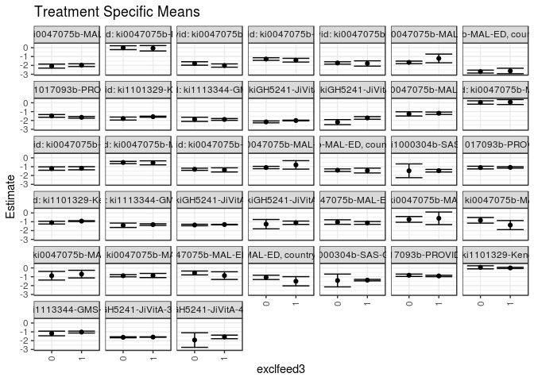

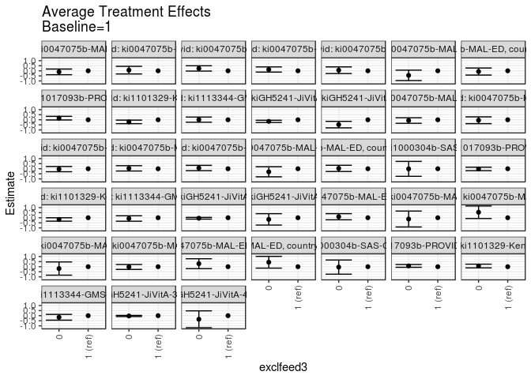

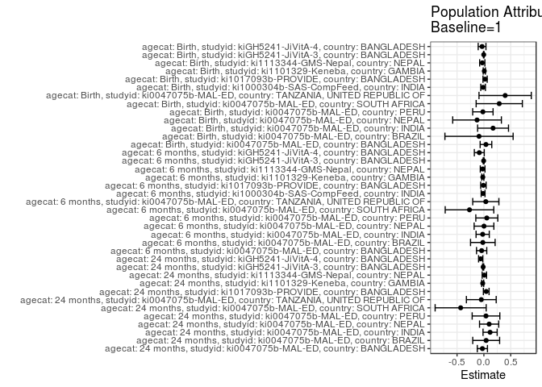

## Results Table

### Parameter: TSM

| agecat | studyid | country | intervention_level | baseline_level | estimate | ci_lower | ci_upper |
| --- | --- | --- | --- | --- | --- | --- | --- |
| Birth | ki0047075b-MAL-ED | BANGLADESH | 1 | NA | -1.1337102 | -1.2957267 | -0.9716936 |
| Birth | ki0047075b-MAL-ED | BANGLADESH | 0 | NA | -1.0356435 | -1.2912625 | -0.7800246 |
| Birth | ki0047075b-MAL-ED | BRAZIL | 1 | NA | -0.6093313 | -1.3210098 | 0.1023471 |
| Birth | ki0047075b-MAL-ED | BRAZIL | 0 | NA | -0.7367189 | -1.0626983 | -0.4107396 |
| Birth | ki0047075b-MAL-ED | INDIA | 1 | NA | -1.3785626 | -1.8946386 | -0.8624867 |
| Birth | ki0047075b-MAL-ED | INDIA | 0 | NA | -0.8385055 | -1.1584810 | -0.5185300 |
| Birth | ki0047075b-MAL-ED | NEPAL | 1 | NA | -0.6962500 | -1.1273498 | -0.2651502 |
| Birth | ki0047075b-MAL-ED | NEPAL | 0 | NA | -0.8800000 | -1.3706027 | -0.3893973 |
| Birth | ki0047075b-MAL-ED | PERU | 1 | NA | -0.8566507 | -1.0911060 | -0.6221953 |
| Birth | ki0047075b-MAL-ED | PERU | 0 | NA | -0.8802478 | -1.0035850 | -0.7569107 |
| Birth | ki0047075b-MAL-ED | SOUTH AFRICA | 1 | NA | -0.8660037 | -1.3013900 | -0.4306175 |
| Birth | ki0047075b-MAL-ED | SOUTH AFRICA | 0 | NA | -0.5685357 | -0.7873895 | -0.3496819 |
| Birth | ki0047075b-MAL-ED | TANZANIA, UNITED REPUBLIC OF | 1 | NA | -1.5048167 | -2.0265571 | -0.9830763 |
| Birth | ki0047075b-MAL-ED | TANZANIA, UNITED REPUBLIC OF | 0 | NA | -1.0639960 | -1.3097853 | -0.8182067 |
| Birth | ki1000304b-SAS-CompFeed | INDIA | 1 | NA | -1.3791852 | -1.4632653 | -1.2951052 |
| Birth | ki1000304b-SAS-CompFeed | INDIA | 0 | NA | -1.4188476 | -2.1434587 | -0.6942365 |
| Birth | ki1017093b-PROVIDE | BANGLADESH | 1 | NA | -0.9076120 | -0.9877967 | -0.8274273 |
| Birth | ki1017093b-PROVIDE | BANGLADESH | 0 | NA | -0.8277994 | -0.9610050 | -0.6945938 |
| Birth | ki1101329-Keneba | GAMBIA | 1 | NA | 0.0021434 | -0.0710703 | 0.0753570 |
| Birth | ki1101329-Keneba | GAMBIA | 0 | NA | 0.0718912 | -0.1028100 | 0.2465925 |
| Birth | ki1113344-GMS-Nepal | NEPAL | 1 | NA | -1.0256472 | -1.1326525 | -0.9186418 |
| Birth | ki1113344-GMS-Nepal | NEPAL | 0 | NA | -1.1835776 | -1.4462251 | -0.9209302 |
| Birth | kiGH5241-JiVitA-3 | BANGLADESH | 1 | NA | -1.5901121 | -1.6137319 | -1.5664923 |
| Birth | kiGH5241-JiVitA-3 | BANGLADESH | 0 | NA | -1.6176616 | -1.6727723 | -1.5625510 |
| Birth | kiGH5241-JiVitA-4 | BANGLADESH | 1 | NA | -1.5736517 | -1.7758436 | -1.3714597 |
| Birth | kiGH5241-JiVitA-4 | BANGLADESH | 0 | NA | -1.9271457 | -2.7502566 | -1.1040348 |
| 6 months | ki0047075b-MAL-ED | BANGLADESH | 1 | NA | -1.1825038 | -1.3154818 | -1.0495257 |
| 6 months | ki0047075b-MAL-ED | BANGLADESH | 0 | NA | -1.2571968 | -1.4945849 | -1.0198087 |
| 6 months | ki0047075b-MAL-ED | BRAZIL | 1 | NA | 0.0804391 | -0.1987470 | 0.3596251 |
| 6 months | ki0047075b-MAL-ED | BRAZIL | 0 | NA | 0.0334215 | -0.1537025 | 0.2205454 |
| 6 months | ki0047075b-MAL-ED | INDIA | 1 | NA | -1.1775999 | -1.3540856 | -1.0011141 |
| 6 months | ki0047075b-MAL-ED | INDIA | 0 | NA | -1.2131127 | -1.4016812 | -1.0245442 |
| 6 months | ki0047075b-MAL-ED | NEPAL | 1 | NA | -0.5656489 | -0.7932297 | -0.3380681 |
| 6 months | ki0047075b-MAL-ED | NEPAL | 0 | NA | -0.5257238 | -0.6559045 | -0.3955430 |
| 6 months | ki0047075b-MAL-ED | PERU | 1 | NA | -1.3653945 | -1.6003819 | -1.1304072 |
| 6 months | ki0047075b-MAL-ED | PERU | 0 | NA | -1.2920685 | -1.4130164 | -1.1711205 |
| 6 months | ki0047075b-MAL-ED | SOUTH AFRICA | 1 | NA | -0.7982754 | -1.2753262 | -0.3212246 |
| 6 months | ki0047075b-MAL-ED | SOUTH AFRICA | 0 | NA | -1.0975518 | -1.2326504 | -0.9624531 |
| 6 months | ki0047075b-MAL-ED | TANZANIA, UNITED REPUBLIC OF | 1 | NA | -1.4391154 | -1.7110366 | -1.1671941 |
| 6 months | ki0047075b-MAL-ED | TANZANIA, UNITED REPUBLIC OF | 0 | NA | -1.3999183 | -1.5435683 | -1.2562682 |
| 6 months | ki1000304b-SAS-CompFeed | INDIA | 1 | NA | -1.4549959 | -1.6008850 | -1.3091069 |
| 6 months | ki1000304b-SAS-CompFeed | INDIA | 0 | NA | -1.4654856 | -2.2428805 | -0.6880907 |
| 6 months | ki1017093b-PROVIDE | BANGLADESH | 1 | NA | -1.0828762 | -1.1661907 | -0.9995617 |
| 6 months | ki1017093b-PROVIDE | BANGLADESH | 0 | NA | -1.1011287 | -1.2531109 | -0.9491465 |
| 6 months | ki1101329-Keneba | GAMBIA | 1 | NA | -0.9290916 | -0.9831298 | -0.8750533 |
| 6 months | ki1101329-Keneba | GAMBIA | 0 | NA | -1.1000642 | -1.2578614 | -0.9422670 |
| 6 months | ki1113344-GMS-Nepal | NEPAL | 1 | NA | -1.3267062 | -1.4216090 | -1.2318034 |
| 6 months | ki1113344-GMS-Nepal | NEPAL | 0 | NA | -1.4021626 | -1.6519663 | -1.1523589 |
| 6 months | kiGH5241-JiVitA-3 | BANGLADESH | 1 | NA | -1.3196921 | -1.3488559 | -1.2905283 |
| 6 months | kiGH5241-JiVitA-3 | BANGLADESH | 0 | NA | -1.3691731 | -1.4535211 | -1.2848252 |
| 6 months | kiGH5241-JiVitA-4 | BANGLADESH | 1 | NA | -1.1139400 | -1.3031769 | -0.9247030 |
| 6 months | kiGH5241-JiVitA-4 | BANGLADESH | 0 | NA | -1.2758192 | -1.8054594 | -0.7461791 |
| 24 months | ki0047075b-MAL-ED | BANGLADESH | 1 | NA | -1.9737576 | -2.1300517 | -1.8174636 |
| 24 months | ki0047075b-MAL-ED | BANGLADESH | 0 | NA | -2.0800140 | -2.3096097 | -1.8504184 |
| 24 months | ki0047075b-MAL-ED | BRAZIL | 1 | NA | -0.0591573 | -0.3646348 | 0.2463202 |
| 24 months | ki0047075b-MAL-ED | BRAZIL | 0 | NA | 0.0060103 | -0.2141834 | 0.2262041 |
| 24 months | ki0047075b-MAL-ED | INDIA | 1 | NA | -2.0149427 | -2.1997428 | -1.8301426 |
| 24 months | ki0047075b-MAL-ED | INDIA | 0 | NA | -1.7802544 | -1.9747176 | -1.5857912 |
| 24 months | ki0047075b-MAL-ED | NEPAL | 1 | NA | -1.4087331 | -1.6196403 | -1.1978260 |
| 24 months | ki0047075b-MAL-ED | NEPAL | 0 | NA | -1.2808890 | -1.4268348 | -1.1349432 |
| 24 months | ki0047075b-MAL-ED | PERU | 1 | NA | -1.7806681 | -2.0794349 | -1.4819013 |
| 24 months | ki0047075b-MAL-ED | PERU | 0 | NA | -1.7241369 | -1.8571590 | -1.5911148 |
| 24 months | ki0047075b-MAL-ED | SOUTH AFRICA | 1 | NA | -1.2099432 | -1.7011908 | -0.7186956 |
| 24 months | ki0047075b-MAL-ED | SOUTH AFRICA | 0 | NA | -1.6596903 | -1.8056259 | -1.5137546 |
| 24 months | ki0047075b-MAL-ED | TANZANIA, UNITED REPUBLIC OF | 1 | NA | -2.6287100 | -2.9364856 | -2.3209343 |
| 24 months | ki0047075b-MAL-ED | TANZANIA, UNITED REPUBLIC OF | 0 | NA | -2.7004779 | -2.8647097 | -2.5362461 |
| 24 months | ki1017093b-PROVIDE | BANGLADESH | 1 | NA | -1.6458217 | -1.7434679 | -1.5481755 |
| 24 months | ki1017093b-PROVIDE | BANGLADESH | 0 | NA | -1.4848722 | -1.6368364 | -1.3329080 |
| 24 months | ki1101329-Keneba | GAMBIA | 1 | NA | -1.5741428 | -1.6311098 | -1.5171757 |
| 24 months | ki1101329-Keneba | GAMBIA | 0 | NA | -1.7836561 | -1.9512103 | -1.6161019 |
| 24 months | ki1113344-GMS-Nepal | NEPAL | 1 | NA | -1.8842019 | -1.9860485 | -1.7823554 |
| 24 months | ki1113344-GMS-Nepal | NEPAL | 0 | NA | -1.8689020 | -2.1045212 | -1.6332827 |
| 24 months | kiGH5241-JiVitA-3 | BANGLADESH | 1 | NA | -2.0050018 | -2.0427861 | -1.9672175 |
| 24 months | kiGH5241-JiVitA-3 | BANGLADESH | 0 | NA | -2.1624692 | -2.2684707 | -2.0564677 |
| 24 months | kiGH5241-JiVitA-4 | BANGLADESH | 1 | NA | -1.7135213 | -1.8616257 | -1.5654169 |
| 24 months | kiGH5241-JiVitA-4 | BANGLADESH | 0 | NA | -2.1898183 | -2.4751694 | -1.9044672 |

### Parameter: E(Y)

| agecat | studyid | country | intervention_level | baseline_level | estimate | ci_lower | ci_upper |
| --- | --- | --- | --- | --- | --- | --- | --- |
| Birth | ki0047075b-MAL-ED | BANGLADESH | NA | NA | -1.0949767 | -1.2319917 | -0.9579618 |
| Birth | ki0047075b-MAL-ED | BRAZIL | NA | NA | -0.6996491 | -0.9856018 | -0.4136965 |
| Birth | ki0047075b-MAL-ED | INDIA | NA | NA | -1.2075610 | -1.5261540 | -0.8889679 |
| Birth | ki0047075b-MAL-ED | NEPAL | NA | NA | -0.8234615 | -1.1896049 | -0.4573182 |
| Birth | ki0047075b-MAL-ED | PERU | NA | NA | -0.8753812 | -0.9932108 | -0.7575515 |
| Birth | ki0047075b-MAL-ED | SOUTH AFRICA | NA | NA | -0.5797000 | -0.7788298 | -0.3805702 |
| Birth | ki0047075b-MAL-ED | TANZANIA, UNITED REPUBLIC OF | NA | NA | -1.1086275 | -1.3310338 | -0.8862211 |
| Birth | ki1000304b-SAS-CompFeed | INDIA | NA | NA | -1.3937088 | -1.5095039 | -1.2779137 |
| Birth | ki1017093b-PROVIDE | BANGLADESH | NA | NA | -0.8851020 | -0.9601332 | -0.8100709 |
| Birth | ki1101329-Keneba | GAMBIA | NA | NA | 0.0098304 | -0.0597854 | 0.0794461 |
| Birth | ki1113344-GMS-Nepal | NEPAL | NA | NA | -1.0555240 | -1.1550843 | -0.9559638 |
| Birth | kiGH5241-JiVitA-3 | BANGLADESH | NA | NA | -1.5928457 | -1.6158667 | -1.5698248 |
| Birth | kiGH5241-JiVitA-4 | BANGLADESH | NA | NA | -1.6073276 | -1.8105798 | -1.4040753 |
| 6 months | ki0047075b-MAL-ED | BANGLADESH | NA | NA | -1.2242918 | -1.3439424 | -1.1046413 |
| 6 months | ki0047075b-MAL-ED | BRAZIL | NA | NA | 0.0609091 | -0.0944768 | 0.2162950 |
| 6 months | ki0047075b-MAL-ED | INDIA | NA | NA | -1.2002381 | -1.3274929 | -1.0729833 |
| 6 months | ki0047075b-MAL-ED | NEPAL | NA | NA | -0.5634068 | -0.6769687 | -0.4498449 |
| 6 months | ki0047075b-MAL-ED | PERU | NA | NA | -1.3108735 | -1.4182407 | -1.2035062 |
| 6 months | ki0047075b-MAL-ED | SOUTH AFRICA | NA | NA | -1.0662227 | -1.1965862 | -0.9358591 |
| 6 months | ki0047075b-MAL-ED | TANZANIA, UNITED REPUBLIC OF | NA | NA | -1.4030503 | -1.5292443 | -1.2768563 |
| 6 months | ki1000304b-SAS-CompFeed | INDIA | NA | NA | -1.4697236 | -1.6333919 | -1.3060553 |
| 6 months | ki1017093b-PROVIDE | BANGLADESH | NA | NA | -1.0916915 | -1.1661176 | -1.0172654 |
| 6 months | ki1101329-Keneba | GAMBIA | NA | NA | -0.9489317 | -1.0001696 | -0.8976937 |
| 6 months | ki1113344-GMS-Nepal | NEPAL | NA | NA | -1.3499849 | -1.4387386 | -1.2612312 |
| 6 months | kiGH5241-JiVitA-3 | BANGLADESH | NA | NA | -1.3240051 | -1.3526414 | -1.2953689 |
| 6 months | kiGH5241-JiVitA-4 | BANGLADESH | NA | NA | -1.1994318 | -1.3808291 | -1.0180345 |
| 24 months | ki0047075b-MAL-ED | BANGLADESH | NA | NA | -2.0016585 | -2.1303297 | -1.8729874 |
| 24 months | ki0047075b-MAL-ED | BRAZIL | NA | NA | -0.0162939 | -0.1929098 | 0.1603221 |
| 24 months | ki0047075b-MAL-ED | INDIA | NA | NA | -1.8994059 | -2.0346781 | -1.7641337 |
| 24 months | ki0047075b-MAL-ED | NEPAL | NA | NA | -1.3109318 | -1.4313748 | -1.1904888 |
| 24 months | ki0047075b-MAL-ED | PERU | NA | NA | -1.7412963 | -1.8630698 | -1.6195228 |
| 24 months | ki0047075b-MAL-ED | SOUTH AFRICA | NA | NA | -1.6424525 | -1.7808926 | -1.5040124 |
| 24 months | ki0047075b-MAL-ED | TANZANIA, UNITED REPUBLIC OF | NA | NA | -2.6768207 | -2.8213178 | -2.5323235 |
| 24 months | ki1017093b-PROVIDE | BANGLADESH | NA | NA | -1.6024221 | -1.6857420 | -1.5191023 |
| 24 months | ki1101329-Keneba | GAMBIA | NA | NA | -1.5961170 | -1.6505261 | -1.5417080 |
| 24 months | ki1113344-GMS-Nepal | NEPAL | NA | NA | -1.8752995 | -1.9688053 | -1.7817937 |
| 24 months | kiGH5241-JiVitA-3 | BANGLADESH | NA | NA | -2.0187325 | -2.0554682 | -1.9819968 |
| 24 months | kiGH5241-JiVitA-4 | BANGLADESH | NA | NA | -1.7726490 | -1.9111913 | -1.6341067 |

### Parameter: ATE

| agecat | studyid | country | intervention_level | baseline_level | estimate | ci_lower | ci_upper |
| --- | --- | --- | --- | --- | --- | --- | --- |
| Birth | ki0047075b-MAL-ED | BANGLADESH | 1 | 1 | 0.0000000 | 0.0000000 | 0.0000000 |
| Birth | ki0047075b-MAL-ED | BANGLADESH | 0 | 1 | 0.0980666 | -0.2051156 | 0.4012489 |
| Birth | ki0047075b-MAL-ED | BRAZIL | 1 | 1 | 0.0000000 | 0.0000000 | 0.0000000 |
| Birth | ki0047075b-MAL-ED | BRAZIL | 0 | 1 | -0.1273876 | -0.9137182 | 0.6589430 |
| Birth | ki0047075b-MAL-ED | INDIA | 1 | 1 | 0.0000000 | 0.0000000 | 0.0000000 |
| Birth | ki0047075b-MAL-ED | INDIA | 0 | 1 | 0.5400571 | -0.0779897 | 1.1581040 |
| Birth | ki0047075b-MAL-ED | NEPAL | 1 | 1 | 0.0000000 | 0.0000000 | 0.0000000 |
| Birth | ki0047075b-MAL-ED | NEPAL | 0 | 1 | -0.1837500 | -0.8368488 | 0.4693488 |
| Birth | ki0047075b-MAL-ED | PERU | 1 | 1 | 0.0000000 | 0.0000000 | 0.0000000 |
| Birth | ki0047075b-MAL-ED | PERU | 0 | 1 | -0.0235972 | -0.2660738 | 0.2188795 |
| Birth | ki0047075b-MAL-ED | SOUTH AFRICA | 1 | 1 | 0.0000000 | 0.0000000 | 0.0000000 |
| Birth | ki0047075b-MAL-ED | SOUTH AFRICA | 0 | 1 | 0.2974680 | -0.1898222 | 0.7847581 |
| Birth | ki0047075b-MAL-ED | TANZANIA, UNITED REPUBLIC OF | 1 | 1 | 0.0000000 | 0.0000000 | 0.0000000 |
| Birth | ki0047075b-MAL-ED | TANZANIA, UNITED REPUBLIC OF | 0 | 1 | 0.4408207 | -0.1394735 | 1.0211150 |
| Birth | ki1000304b-SAS-CompFeed | INDIA | 1 | 1 | 0.0000000 | 0.0000000 | 0.0000000 |
| Birth | ki1000304b-SAS-CompFeed | INDIA | 0 | 1 | -0.0396624 | -0.7382457 | 0.6589209 |
| Birth | ki1017093b-PROVIDE | BANGLADESH | 1 | 1 | 0.0000000 | 0.0000000 | 0.0000000 |
| Birth | ki1017093b-PROVIDE | BANGLADESH | 0 | 1 | 0.0798126 | -0.0599573 | 0.2195826 |
| Birth | ki1101329-Keneba | GAMBIA | 1 | 1 | 0.0000000 | 0.0000000 | 0.0000000 |
| Birth | ki1101329-Keneba | GAMBIA | 0 | 1 | 0.0697479 | -0.1117896 | 0.2512853 |
| Birth | ki1113344-GMS-Nepal | NEPAL | 1 | 1 | 0.0000000 | 0.0000000 | 0.0000000 |
| Birth | ki1113344-GMS-Nepal | NEPAL | 0 | 1 | -0.1579305 | -0.4416431 | 0.1257822 |
| Birth | kiGH5241-JiVitA-3 | BANGLADESH | 1 | 1 | 0.0000000 | 0.0000000 | 0.0000000 |
| Birth | kiGH5241-JiVitA-3 | BANGLADESH | 0 | 1 | -0.0275495 | -0.0829185 | 0.0278195 |
| Birth | kiGH5241-JiVitA-4 | BANGLADESH | 1 | 1 | 0.0000000 | 0.0000000 | 0.0000000 |
| Birth | kiGH5241-JiVitA-4 | BANGLADESH | 0 | 1 | -0.3534940 | -1.1815229 | 0.4745349 |
| 6 months | ki0047075b-MAL-ED | BANGLADESH | 1 | 1 | 0.0000000 | 0.0000000 | 0.0000000 |
| 6 months | ki0047075b-MAL-ED | BANGLADESH | 0 | 1 | -0.0746930 | -0.3476044 | 0.1982183 |
| 6 months | ki0047075b-MAL-ED | BRAZIL | 1 | 1 | 0.0000000 | 0.0000000 | 0.0000000 |
| 6 months | ki0047075b-MAL-ED | BRAZIL | 0 | 1 | -0.0470176 | -0.3826174 | 0.2885822 |
| 6 months | ki0047075b-MAL-ED | INDIA | 1 | 1 | 0.0000000 | 0.0000000 | 0.0000000 |
| 6 months | ki0047075b-MAL-ED | INDIA | 0 | 1 | -0.0355129 | -0.2941005 | 0.2230748 |
| 6 months | ki0047075b-MAL-ED | NEPAL | 1 | 1 | 0.0000000 | 0.0000000 | 0.0000000 |
| 6 months | ki0047075b-MAL-ED | NEPAL | 0 | 1 | 0.0399251 | -0.2224725 | 0.3023228 |
| 6 months | ki0047075b-MAL-ED | PERU | 1 | 1 | 0.0000000 | 0.0000000 | 0.0000000 |
| 6 months | ki0047075b-MAL-ED | PERU | 0 | 1 | 0.0733261 | -0.1911321 | 0.3377842 |
| 6 months | ki0047075b-MAL-ED | SOUTH AFRICA | 1 | 1 | 0.0000000 | 0.0000000 | 0.0000000 |
| 6 months | ki0047075b-MAL-ED | SOUTH AFRICA | 0 | 1 | -0.2992763 | -0.7953798 | 0.1968272 |
| 6 months | ki0047075b-MAL-ED | TANZANIA, UNITED REPUBLIC OF | 1 | 1 | 0.0000000 | 0.0000000 | 0.0000000 |
| 6 months | ki0047075b-MAL-ED | TANZANIA, UNITED REPUBLIC OF | 0 | 1 | 0.0391971 | -0.2665633 | 0.3449575 |
| 6 months | ki1000304b-SAS-CompFeed | INDIA | 1 | 1 | 0.0000000 | 0.0000000 | 0.0000000 |
| 6 months | ki1000304b-SAS-CompFeed | INDIA | 0 | 1 | -0.0104897 | -0.7471588 | 0.7261794 |
| 6 months | ki1017093b-PROVIDE | BANGLADESH | 1 | 1 | 0.0000000 | 0.0000000 | 0.0000000 |
| 6 months | ki1017093b-PROVIDE | BANGLADESH | 0 | 1 | -0.0182525 | -0.1902917 | 0.1537867 |
| 6 months | ki1101329-Keneba | GAMBIA | 1 | 1 | 0.0000000 | 0.0000000 | 0.0000000 |
| 6 months | ki1101329-Keneba | GAMBIA | 0 | 1 | -0.1709726 | -0.3374358 | -0.0045094 |
| 6 months | ki1113344-GMS-Nepal | NEPAL | 1 | 1 | 0.0000000 | 0.0000000 | 0.0000000 |
| 6 months | ki1113344-GMS-Nepal | NEPAL | 0 | 1 | -0.0754564 | -0.3431810 | 0.1922681 |
| 6 months | kiGH5241-JiVitA-3 | BANGLADESH | 1 | 1 | 0.0000000 | 0.0000000 | 0.0000000 |
| 6 months | kiGH5241-JiVitA-3 | BANGLADESH | 0 | 1 | -0.0494810 | -0.1345929 | 0.0356308 |
| 6 months | kiGH5241-JiVitA-4 | BANGLADESH | 1 | 1 | 0.0000000 | 0.0000000 | 0.0000000 |
| 6 months | kiGH5241-JiVitA-4 | BANGLADESH | 0 | 1 | -0.1618793 | -0.7227615 | 0.3990029 |
| 24 months | ki0047075b-MAL-ED | BANGLADESH | 1 | 1 | 0.0000000 | 0.0000000 | 0.0000000 |
| 24 months | ki0047075b-MAL-ED | BANGLADESH | 0 | 1 | -0.1062564 | -0.3849839 | 0.1724711 |
| 24 months | ki0047075b-MAL-ED | BRAZIL | 1 | 1 | 0.0000000 | 0.0000000 | 0.0000000 |
| 24 months | ki0047075b-MAL-ED | BRAZIL | 0 | 1 | 0.0651676 | -0.3117712 | 0.4421065 |
| 24 months | ki0047075b-MAL-ED | INDIA | 1 | 1 | 0.0000000 | 0.0000000 | 0.0000000 |
| 24 months | ki0047075b-MAL-ED | INDIA | 0 | 1 | 0.2346883 | -0.0281611 | 0.4975377 |
| 24 months | ki0047075b-MAL-ED | NEPAL | 1 | 1 | 0.0000000 | 0.0000000 | 0.0000000 |
| 24 months | ki0047075b-MAL-ED | NEPAL | 0 | 1 | 0.1278441 | -0.1275313 | 0.3832195 |
| 24 months | ki0047075b-MAL-ED | PERU | 1 | 1 | 0.0000000 | 0.0000000 | 0.0000000 |
| 24 months | ki0047075b-MAL-ED | PERU | 0 | 1 | 0.0565313 | -0.2711024 | 0.3841649 |
| 24 months | ki0047075b-MAL-ED | SOUTH AFRICA | 1 | 1 | 0.0000000 | 0.0000000 | 0.0000000 |
| 24 months | ki0047075b-MAL-ED | SOUTH AFRICA | 0 | 1 | -0.4497470 | -0.9637244 | 0.0642303 |
| 24 months | ki0047075b-MAL-ED | TANZANIA, UNITED REPUBLIC OF | 1 | 1 | 0.0000000 | 0.0000000 | 0.0000000 |
| 24 months | ki0047075b-MAL-ED | TANZANIA, UNITED REPUBLIC OF | 0 | 1 | -0.0717679 | -0.4197725 | 0.2762367 |
| 24 months | ki1017093b-PROVIDE | BANGLADESH | 1 | 1 | 0.0000000 | 0.0000000 | 0.0000000 |
| 24 months | ki1017093b-PROVIDE | BANGLADESH | 0 | 1 | 0.1609495 | -0.0176907 | 0.3395897 |
| 24 months | ki1101329-Keneba | GAMBIA | 1 | 1 | 0.0000000 | 0.0000000 | 0.0000000 |
| 24 months | ki1101329-Keneba | GAMBIA | 0 | 1 | -0.2095133 | -0.3851617 | -0.0338649 |
| 24 months | ki1113344-GMS-Nepal | NEPAL | 1 | 1 | 0.0000000 | 0.0000000 | 0.0000000 |
| 24 months | ki1113344-GMS-Nepal | NEPAL | 0 | 1 | 0.0153000 | -0.2401739 | 0.2707739 |
| 24 months | kiGH5241-JiVitA-3 | BANGLADESH | 1 | 1 | 0.0000000 | 0.0000000 | 0.0000000 |
| 24 months | kiGH5241-JiVitA-3 | BANGLADESH | 0 | 1 | -0.1574674 | -0.2664307 | -0.0485041 |
| 24 months | kiGH5241-JiVitA-4 | BANGLADESH | 1 | 1 | 0.0000000 | 0.0000000 | 0.0000000 |
| 24 months | kiGH5241-JiVitA-4 | BANGLADESH | 0 | 1 | -0.4762970 | -0.7981220 | -0.1544720 |

### Parameter: PAR

| agecat | studyid | country | intervention_level | baseline_level | estimate | ci_lower | ci_upper |
| --- | --- | --- | --- | --- | --- | --- | --- |
| Birth | ki0047075b-MAL-ED | BANGLADESH | 1 | NA | 0.0387334 | -0.0695552 | 0.1470221 |
| Birth | ki0047075b-MAL-ED | BRAZIL | 1 | NA | -0.0903178 | -0.7255587 | 0.5449231 |
| Birth | ki0047075b-MAL-ED | INDIA | 1 | NA | 0.1710017 | -0.1167952 | 0.4587985 |
| Birth | ki0047075b-MAL-ED | NEPAL | 1 | NA | -0.1272115 | -0.5805774 | 0.3261543 |
| Birth | ki0047075b-MAL-ED | PERU | 1 | NA | -0.0187305 | -0.2085084 | 0.1710474 |
| Birth | ki0047075b-MAL-ED | SOUTH AFRICA | 1 | NA | 0.2863037 | -0.1440688 | 0.7166762 |
| Birth | ki0047075b-MAL-ED | TANZANIA, UNITED REPUBLIC OF | 1 | NA | 0.3961893 | -0.0909210 | 0.8832996 |
| Birth | ki1000304b-SAS-CompFeed | INDIA | 1 | NA | -0.0145236 | -0.0577567 | 0.0287095 |
| Birth | ki1017093b-PROVIDE | BANGLADESH | 1 | NA | 0.0225100 | -0.0167733 | 0.0617932 |
| Birth | ki1101329-Keneba | GAMBIA | 1 | NA | 0.0076870 | -0.0127061 | 0.0280802 |
| Birth | ki1113344-GMS-Nepal | NEPAL | 1 | NA | -0.0298768 | -0.0785568 | 0.0188031 |
| Birth | kiGH5241-JiVitA-3 | BANGLADESH | 1 | NA | -0.0027336 | -0.0079973 | 0.0025301 |
| Birth | kiGH5241-JiVitA-4 | BANGLADESH | 1 | NA | -0.0336759 | -0.1059971 | 0.0386453 |
| 6 months | ki0047075b-MAL-ED | BANGLADESH | 1 | NA | -0.0417881 | -0.1373130 | 0.0537369 |
| 6 months | ki0047075b-MAL-ED | BRAZIL | 1 | NA | -0.0195300 | -0.2486005 | 0.2095404 |
| 6 months | ki0047075b-MAL-ED | INDIA | 1 | NA | -0.0226382 | -0.1456983 | 0.1004218 |
| 6 months | ki0047075b-MAL-ED | NEPAL | 1 | NA | 0.0022421 | -0.1815457 | 0.1860300 |
| 6 months | ki0047075b-MAL-ED | PERU | 1 | NA | 0.0545211 | -0.1504240 | 0.2594662 |
| 6 months | ki0047075b-MAL-ED | SOUTH AFRICA | 1 | NA | -0.2679472 | -0.7204658 | 0.1845713 |
| 6 months | ki0047075b-MAL-ED | TANZANIA, UNITED REPUBLIC OF | 1 | NA | 0.0360650 | -0.2076365 | 0.2797666 |
| 6 months | ki1000304b-SAS-CompFeed | INDIA | 1 | NA | -0.0147277 | -0.0507565 | 0.0213012 |
| 6 months | ki1017093b-PROVIDE | BANGLADESH | 1 | NA | -0.0088153 | -0.0593489 | 0.0417183 |
| 6 months | ki1101329-Keneba | GAMBIA | 1 | NA | -0.0198401 | -0.0390542 | -0.0006260 |
| 6 months | ki1113344-GMS-Nepal | NEPAL | 1 | NA | -0.0232787 | -0.0669747 | 0.0204174 |
| 6 months | kiGH5241-JiVitA-3 | BANGLADESH | 1 | NA | -0.0043131 | -0.0117723 | 0.0031462 |
| 6 months | kiGH5241-JiVitA-4 | BANGLADESH | 1 | NA | -0.0854919 | -0.1779600 | 0.0069762 |
| 24 months | ki0047075b-MAL-ED | BANGLADESH | 1 | NA | -0.0279009 | -0.1224223 | 0.0666204 |
| 24 months | ki0047075b-MAL-ED | BRAZIL | 1 | NA | 0.0428634 | -0.2074290 | 0.2931559 |
| 24 months | ki0047075b-MAL-ED | INDIA | 1 | NA | 0.1155368 | -0.0162072 | 0.2472807 |
| 24 months | ki0047075b-MAL-ED | NEPAL | 1 | NA | 0.0978013 | -0.0811725 | 0.2767752 |
| 24 months | ki0047075b-MAL-ED | PERU | 1 | NA | 0.0393718 | -0.2183710 | 0.2971147 |
| 24 months | ki0047075b-MAL-ED | SOUTH AFRICA | 1 | NA | -0.4325093 | -0.9081326 | 0.0431140 |
| 24 months | ki0047075b-MAL-ED | TANZANIA, UNITED REPUBLIC OF | 1 | NA | -0.0481107 | -0.3256245 | 0.2294031 |
| 24 months | ki1017093b-PROVIDE | BANGLADESH | 1 | NA | 0.0433996 | -0.0096694 | 0.0964685 |
| 24 months | ki1101329-Keneba | GAMBIA | 1 | NA | -0.0219742 | -0.0402792 | -0.0036693 |
| 24 months | ki1113344-GMS-Nepal | NEPAL | 1 | NA | 0.0089025 | -0.0321013 | 0.0499062 |
| 24 months | kiGH5241-JiVitA-3 | BANGLADESH | 1 | NA | -0.0137307 | -0.0232041 | -0.0042573 |
| 24 months | kiGH5241-JiVitA-4 | BANGLADESH | 1 | NA | -0.0591277 | -0.0986911 | -0.0195643 |